# Mesh convergence study (GCI)

# 6. Pressure field convergence

§4 and §5 work with **one number per mesh**: an integral coefficient. That is enough to select a triplet, but it says nothing about *where* the solution converges and where it does not. An integral can agree between two meshes by cancelling errors of opposite sign distributed along the chord.

This section looks at the full distribution. For each flight condition the $-C_p(x/c)$ curves of the **three meshes of the winning triplet** are overlaid, upper and lower surface. If the field is converged the three curves are indistinguishable; if it is not, they separate exactly where the mesh still governs the solution.

Coordinates are normalised by the chord, and the two surfaces are separated by the sign of $z$ — the aerofoil lies in the $x$–$z$ plane on a single spanwise plane, so the split is exact and needs no further geometric criterion.

aoa_0.022_m_1.071

aoa_0.022_m_1.386

aoa_3.303_m_0.541

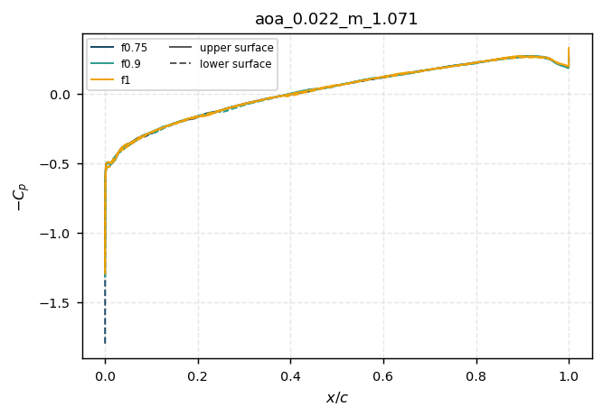

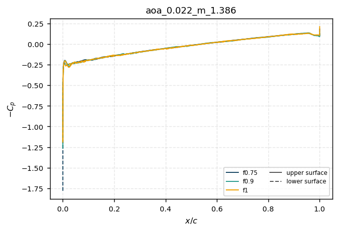

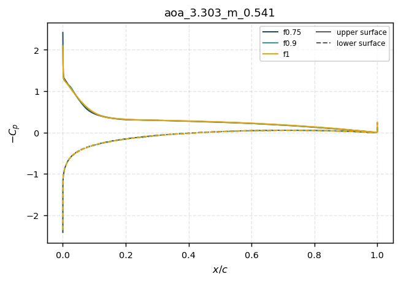

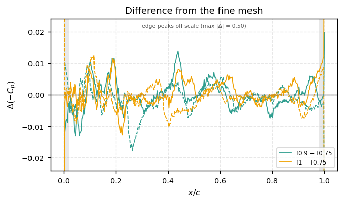

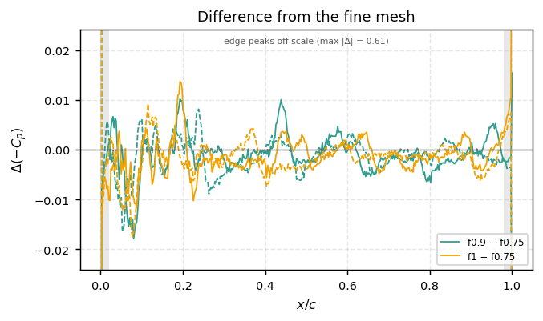

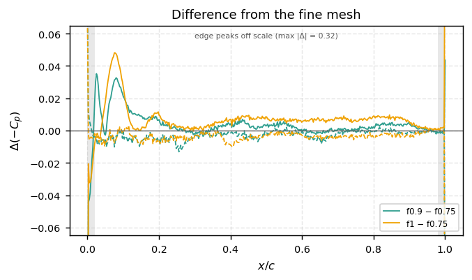

Top: −C<sub>p</sub> distribution of the three meshes of the winning triplet (solid = upper surface, dashed = lower). Bottom: difference of each mesh from the fine one, after resampling both onto a common x/c grid. The grey band marks the 2% of chord at each end, excluded from the statistics; the axis is framed on the interior, so the edge peaks run off scale.

Difference between the pressure curves

| database | comparison | RMS Δ(-Cp) interior | max \|Δ\| interior | max \|Δ\| incl. edges | relative RMS [%] |
| --- | --- | --- | --- | --- | --- |
| aoa_0.022_m_1.071 | f0.9 − f0.75 | 0.004507 | 0.01791 | 0.4747 | 0.2118 |
| aoa_0.022_m_1.071 | f1 − f0.75 | 0.003844 | 0.0128 | 0.4978 | 0.1806 |
| aoa_0.022_m_1.386 | f0.9 − f0.75 | 0.00387 | 0.01793 | 0.51 | 0.1944 |
| aoa_0.022_m_1.386 | f1 − f0.75 | 0.003709 | 0.01768 | 0.6052 | 0.1863 |
| aoa_3.303_m_0.541 | f0.9 − f0.75 | 0.006246 | 0.03521 | 0.2916 | 0.1289 |
| aoa_3.303_m_0.541 | f1 − f0.75 | 0.008307 | 0.04809 | 0.3224 | 0.1714 |

Difference statistics. **Interior** excludes the 2% of chord at each edge, where the aerofoil is sharp and C<sub>p</sub> is singular. The relative RMS is referred to the range of the −C<sub>p</sub> curve itself.

**The exception is at the edges, and it is structural.** The differences concentrate at the leading and trailing edges, where the aerofoil is sharp and $C_p$ is singular. No mesh in this family resolves the peak there: each refinement simply captures it slightly higher, without converging. That is the expected behaviour on a geometry with sharp edges, and the reason the shaded zones are excluded from the table statistics — two cells cannot be allowed to dominate a norm taken over several thousand.

**It also explains why the previous approach failed.** A scalar reduction of the field — the RMS($C_p$) this section replaces — mixes the converged chord with the two peaks that are not converged, and inherits all the mesh sensitivity of the latter. Hence the erratic triplet ordering it produced. The useful information was in the distribution, not in the scalar.

# 7. Reading the results

Study outcome

Winning triplet **f0.75 / f0.9 / f1** · recommended mesh **f0.75**  
Discretisation uncertainty on CoefDrag: **10.7 % – 29.0 %** depending on the flight condition, with observed orders from 0.65 to 1.65.

### What the study does establish

**One triplet works at all three flight conditions**, selected by an explicit and reproducible criterion: a score on Richardson's own hypotheses — never on the GCI, which is the quantity being measured — followed by a *minimax* consensus across the three rankings. Changing the §4.2 weights changes the ordering, but the procedure is written down and auditable.

**The convergence filter is indispensable, though not for the reason expected.** It discards triplets built on simulations with residuals of $10^{-1}$, which are indefensible however attractive their GCI. But it does **not** explain the scatter: where nearly every simulation converges, the distribution is the same before and after (§4.2). The threshold itself, on the other hand, is immaterial: between $10^{-4}$ and $10^{-3}$ the surviving mesh set is identical.

### What the study does not establish

**It does not demonstrate that the solution is mesh-converged.** The winner's observed orders fall below the nominal second order of the scheme, and its GCI runs to several tens of per cent at two of the three conditions. The recommended mesh is the best these data support; it is not a mesh with small uncertainty.

**The study is limited by one flight condition.** Of the eleven simulations per condition, the most restrictive leaves only four converged, and the winner necessarily comes from the handful of combinations those four allow. The other two conditions offer many more candidates that cannot be used, because the triplet has to hold at all three.

**The winner is weakly refined.** Its ratios are $r_{21} = 1.2$ and $r_{32} = 1.11$, far from the desirable $r = 2$. That is not a choice of the method but of what is available: the converged meshes common to all three conditions sit very close together.

**The pressure field does converge, even though the integral coefficients do not show it.** §6 overlays the $-C_p(x/c)$ curves of the winning triplet and they come out indistinguishable along the whole chord. That is the strongest evidence that the recommended mesh captures the physics; what does not converge are the **sharp edges**, where $C_p$ is singular and no mesh in the family resolves the peak. Those two points are what contaminate both the integral coefficients and any scalar reduction of the field.

Where the constraint comes from

| database | simulations | excluded (§2) | converged and usable | not converged | admissible triplets | winner's rank |
| --- | --- | --- | --- | --- | --- | --- |
| aoa_0.022_m_1.071 | 11 | 1 | 4 | 6 | 2 | 2 |
| aoa_0.022_m_1.386 | 11 | 1 | 8 | 2 | 21 | 8 |
| aoa_3.303_m_0.541 | 11 | 1 | 10 | 0 | 61 | 30 |

**aoa_0.022_m_1.071** is the limiting condition: with so few converged meshes, its combinations are what bound the consensus.

### Recommendation

1. **Use the recommended mesh of §4.5 for production**, reporting its $C_D$ together with the uncertainty band from that same table. It is the fine mesh of the winning triplet and the only one whose uncertainty is quantified.
2. **Drive the remaining simulations at the limiting condition to convergence.** This is by far the highest-return action: it requires no new mesh, only further iteration of runs that already exist, and it would multiply the available triplets.
3. **Regenerate `f0.95`**, which currently adds no wall refinement (§2).
4. **Find out why the observed orders come out low** before refining further. The usual causes are insufficient iterative convergence, mesh topology changes between levels, or a solution that is not genuinely steady. Tightening the mesh fixes none of them.
5. For future studies, **generate the family in geometric progression** ($f$, $2f$, $4f$) and converge all three levels hard: three well-spaced, well-converged runs give a more trustworthy GCI than eleven closely spaced and half-converged ones.

Report generated automatically by `build_gci_report.py` from `coda_single_GCI_en.ipynb`, using FotR (FRODO · `CODA_SINGLE` format). Convergence computations come from `CODASingleStats.richardson`; the per-mesh reductions from `CODASingleSets.reduce_cases`; the solver convergence verdict from `CODAResiduals.update_converged_state`.